# COMPSCIX 415.2 Homework 8

Rachel Hollowgrass

3/27/2018

```r
# load packages
library(tidyverse)
library(broom)
```

### Exercise 1

Load the train.csv dataset into R. How many observations and columns are there?

```r
file_path <- '../data/homework8/train.csv'
train <- read_csv(file_path)
train
```

```
## # A tibble: 891 x 12
##    PassengerId Survived Pclass Name   Sex     Age SibSp Parch Ticket  Fare
##          <int>    <int>  <int> <chr>  <chr> <dbl> <int> <int> <chr>  <dbl>
##  1           1        0      3 Braun… male  22.0      1     0 A/5 2…  7.25
##  2           2        1      1 Cumin… fema… 38.0      1     0 PC 17… 71.3
##  3           3        1      3 Heikk… fema… 26.0      0     0 STON/…  7.92
##  4           4        1      1 Futre… fema… 35.0      1     0 113803 53.1
##  5           5        0      3 Allen… male  35.0      0     0 373450  8.05
##  6           6        0      3 Moran… male  NA        0     0 330877  8.46
##  7           7        0      1 McCar… male  54.0      0     0 17463  51.9
##  8           8        0      3 Palss… male   2.00     3     1 349909 21.1
##  9           9        1      3 Johns… fema… 27.0      0     2 347742 11.1
## 10          10        1      2 Nasse… fema… 14.0      1     0 237736 30.1
## # ... with 881 more rows, and 2 more variables: Cabin <chr>,
## #   Embarked <chr>
```

*There are:*

- *891 observations*
- *12 columns of variables (including the ID number )*

Convert the target variable to a factor because it will be loaded into R as an integer by default.

```r
# Survived is not a continous variable, so make a factor for it.
train <- train %>% mutate(Survived =
  factor(case_when(
                  Survived == 1 ~ 'True',
                  Survived == 0 ~ 'False'
                  ),
            levels = c('True', 'False')
         )
  )

# Pclass is also not a continous variable, so make a factor for it.
train <- train %>% mutate(Pclass =
  factor(case_when(
                  Pclass == 1 ~ 'First',
                  Pclass == 2 ~ 'Second',
                  Pclass == 3 ~ 'Third'
                  ),
            levels = c('First', 'Second', 'Third')
         )
  )
train
```

```
## # A tibble: 891 x 12
##    PassengerId Survived Pclass Name   Sex     Age SibSp Parch Ticket  Fare
##          <int> <fct>    <fct>  <chr>  <chr> <dbl> <int> <int> <chr>  <dbl>
##  1           1 False    Third  Braun… male  22.0      1     0 A/5 2…  7.25
##  2           2 True     First  Cumin… fema… 38.0      1     0 PC 17… 71.3
##  3           3 True     Third  Heikk… fema… 26.0      0     0 STON/…  7.92
##  4           4 True     First  Futre… fema… 35.0      1     0 113803 53.1
##  5           5 False    Third  Allen… male  35.0      0     0 373450  8.05
##  6           6 False    Third  Moran… male  NA        0     0 330877  8.46
##  7           7 False    First  McCar… male  54.0      0     0 17463  51.9
##  8           8 False    Third  Palss… male   2.00     3     1 349909 21.1
##  9           9 True     Third  Johns… fema… 27.0      0     2 347742 11.1
## 10          10 True     Second Nasse… fema… 14.0      1     0 237736 30.1
## # ... with 881 more rows, and 2 more variables: Cabin <chr>,
## #   Embarked <chr>
```

### Exercise 2

Our first step is to randomly split the data into train and test datasets. We will use a 70/30 split, and use the random seed of 29283 so that we all should get the same training and test set.

```r
set.seed(29283)

train_set <- train %>% sample_frac(.7)

test_set <- train %>% filter(!(train$PassengerId %in% train_set$PassengerId))
```

### Exercise 3

Our target is called `Survived`. First, fit a logistic regression model using `Pclass`, `Sex`, `Fare` as your three features. Fit the model using the `glm()` function.

Ask **yourself** these questions before fitting the model:

- What kind of relationship will these features have with the probability of survival?  
  *I expect that `Pclass` will have a negative correlation (lower values such as 1st and 2nd class = higher probability of survival), `Fare` will have a positive correlation (higher fare = higher probability), and when `Sex` = `female` it will also have a positive correlation.*
- Are these good features, given the problem we are trying to solve?  
  *`Pclass` and `Fare` seem redundant. Based on the phrase “Women and children first!” I might have chosen `Pclass`, `Sex` and `Age` instead.*

```r
library(broom)

# Fit a model with intercept only
mod_1 <- glm(Survived ~ Pclass + Sex + Fare, data = train_set, family = 'binomial')

# take a look at the features and coefficients
tidy(mod_1)
```

```
##           term     estimate   std.error  statistic      p.value
## 1  (Intercept) -2.184273582 0.328033129 -6.6586981 2.762637e-11
## 2 PclassSecond  0.633237694 0.321525515  1.9694788 4.889813e-02
## 3  PclassThird  1.701756611 0.298007147  5.7104557 1.126741e-08
## 4      Sexmale  2.834542001 0.229213455 12.3663857 3.973000e-35
## 5         Fare -0.002266955 0.002360593 -0.9603331 3.368876e-01
```

### Exercise 4

Now, let’s fit a model using a classification tree, using the same features and plot the final decision tree. Use the code below for help.

Answer these questions:

- Describe in words one path a Titanic passenger might take down the tree. (Hint: look at your tree, choose a path from the top to a terminal node, and describe the path like this - *a male passenger who paid a fare > 30 and was in first class has a high probability of survival)*  
  *A female passenger who was in first or second class had the highest probability of survival.*
- Does anything surprise you about the fitted tree?  
  *Class and ticket price seemed to have nothing to do with the probability of survival for male passengers.*

```r
library(rpart)
library(partykit)
```

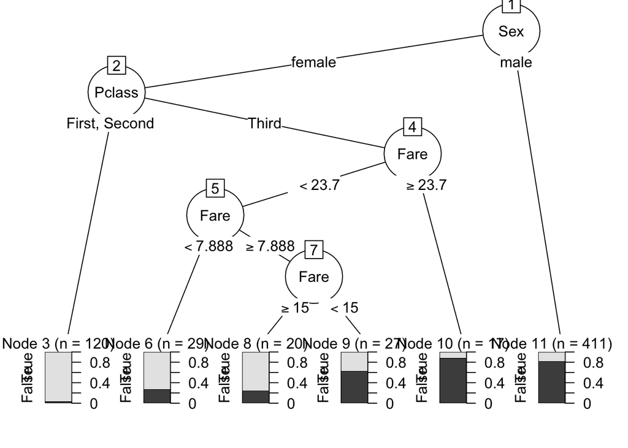

```r
tree_mod <- rpart(Survived ~ Pclass + Sex + Fare, data = train_set)

plot(as.party(tree_mod))
```

### Exercise 5

Evaluate both the logistic regression model and classification tree on the `test_set`. First, use the `predict()` function to get the model predictions for the testing set. Use the code below for help.

It may seem odd that we are using the same `predict()` function to make predictions for two completely different types of models (logistic regression and classification tree). This is a feature of R that there are many generic functions that you can apply to different R objects. Depending on the class of the object that is passed to the generic function, R will know which definition of the generic function to use on that object.

```r
test_logit <- predict(mod_1, newdata = test_set, type = 'response')
test_tree <- predict(tree_mod, newdata = test_set)[,2]
```

1. Next, we will plot the ROC curves from both models using the code below. Don’t just copy and paste the code. Go through it line by line and see what it is doing. Recall that predictions from your decision tree are given as a two column matrix.

```r
library(ROCR)
```

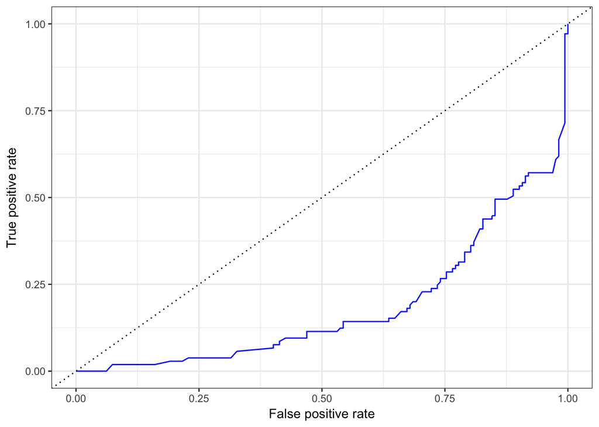

```r
# create the prediction objects for both models
pred_logit <- prediction(predictions = test_logit, labels = test_set$Survived)
pred_tree <- prediction(predictions = test_tree, labels = test_set$Survived)

# get the FPR and TPR for the logistic model
# recall that the ROC curve plots the FPR on the x-axis
perf_logit <- performance(pred_logit, measure = 'tpr', x.measure = 'fpr')
perf_logit_tbl <- tibble(perf_logit@x.values[[1]], perf_logit@y.values[[1]])

# Change the names of the columns of the tibble
names(perf_logit_tbl) <- c('fpr', 'tpr')

# get the FPR and TPR for the tree model
perf_tree <- performance(pred_tree, measure = 'tpr', x.measure = 'fpr')
perf_tree_tbl <- tibble(perf_tree@x.values[[1]], perf_tree@y.values[[1]])

# Change the names of the columns of the tibble
names(perf_tree_tbl) <- c('fpr', 'tpr')

# Plotting function for plotting a nice ROC curve using ggplot
plot_roc <- function(perf_tbl) {
  p <- ggplot(data = perf_tbl, aes(x = fpr, y = tpr)) +
  geom_line(color = 'blue') +
  geom_abline(intercept = 0, slope = 1, lty = 3) +
  labs(x = 'False positive rate', y = 'True positive rate') +
  theme_bw()
  return(p)
}

# Create the ROC curves using the function we created above
plot_roc(perf_logit_tbl)
```

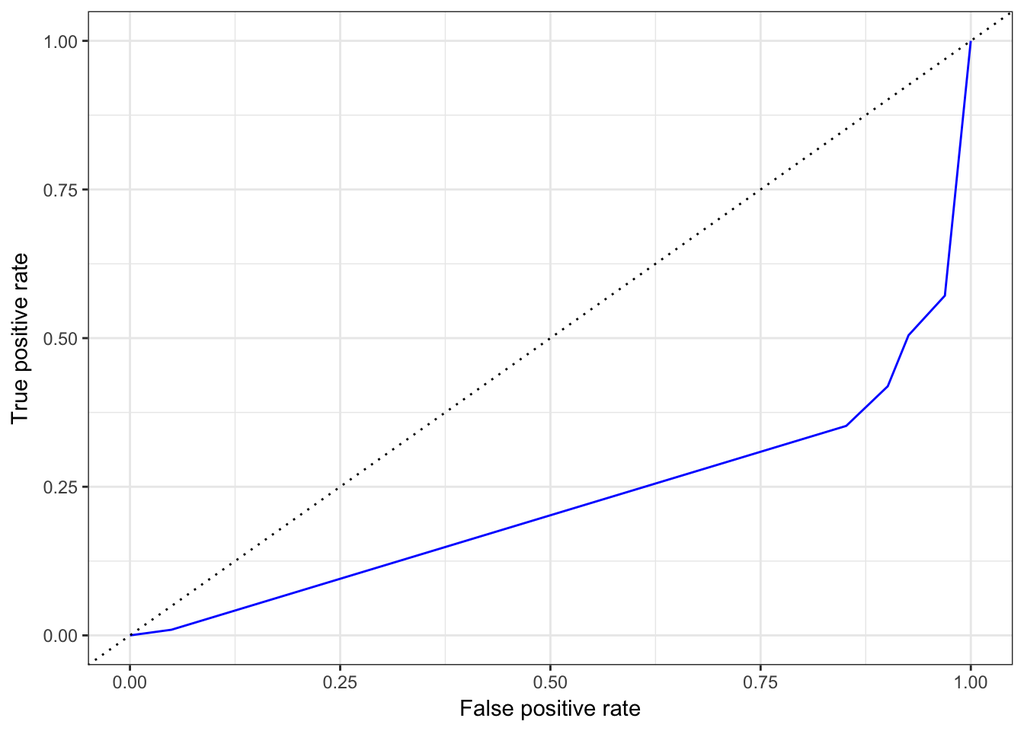

```r
plot_roc(perf_tree_tbl)
```

2. Now, use the `performance()` function to calculate the area under the curve (AUC) for both ROC curves. Check `?performance` for help on plugging in the right `measure` argument.

```r
# calculate the AUC
auc_logit <- performance(pred_logit, measure = "auc")
auc_tree <- performance(pred_tree, measure = "auc")

# extract the AUC value
auc_logit@y.values[[1]]
```

```
## [1] 0.1852146
```

```r
auc_tree@y.values[[1]]
```

```
## [1] 0.223398
```

What do you notice about the ROC curves and the AUC values? Are the models performing well? Is the logistic regression model doing better, worse, or about the same as the classification tree?

_The tree is performing slightly better than the logistic regression, but only a little. Because both are under .25, they each have more false positives than random chance.

3. Lastly, pick a probability cutoff by looking at the ROC curves. You pick, there’s no right answer (but there is a wrong answer - make sure to pick something between 0 and 1). Using that probability cutoff, create the confusion matrix for each model by following these steps:
1. Pick a cutoff value.
2. Append the predicted probability values from each model (you created these at the beginning of Exercise 5) to your `test_set` tibble using `mutate()`.
3. Create a new column for the predicted class from each model using `mutate()` and `case_when()`. Your new predicted class columns can have two possible values: `yes` or `no` which represents whether or not the passenger is predicted to have survived or not given the predicted probability.
4. You should now have 4 extra columns added to your `test_set` tibble, two columns of predicted probabilities, and two columns of the predicted categories based on your probability cutoff.
5. Now create the table using the code below:

*My cutoff value is 0.3.*

```r
cutoff = .3
test_set <- test_set %>% mutate(logit_pp = test_logit)
test_set <- test_set %>% mutate(tree_pp = test_tree)
test_set <- test_set %>% mutate(class_logit =
  factor(case_when(logit_pp < cutoff ~ 'No',
                  logit_pp >= cutoff ~ 'Yes'),
             levels = c('No', 'Yes')))
test_set <- test_set %>% mutate(class_tree =
  factor(case_when(tree_pp < cutoff ~ 'No',
                  tree_pp >= cutoff ~ 'Yes'),
             levels = c('No', 'Yes')))

# View test_set, to validate:
test_set
```

```
## # A tibble: 267 x 16
##    PassengerId Survived Pclass Name  Sex     Age SibSp Parch Ticket   Fare
##          <int> <fct>    <fct>  <chr> <chr> <dbl> <int> <int> <chr>   <dbl>
##  1           1 False    Third  Brau… male  22.0      1     0 A/5 2…   7.25
##  2           2 True     First  Cumi… fema… 38.0      1     0 PC 17…  71.3
##  3           5 False    Third  Alle… male  35.0      0     0 373450   8.05
##  4          12 True     First  Bonn… fema… 58.0      0     0 113783  26.6
##  5          19 False    Third  Vand… fema… 31.0      1     0 345763  18.0
##  6          23 True     Third  "McG… fema… 15.0      0     0 330923   8.03
##  7          25 False    Third  Pals… fema…  8.00     3     1 349909  21.1
##  8          28 False    First  Fort… male  19.0      3     2 19950  263
##  9          30 False    Third  Todo… male  NA        0     0 349216   7.90
## 10          33 True     Third  Glyn… fema… NA        0     0 335677   7.75
## # ... with 257 more rows, and 6 more variables: Cabin <chr>,
## #   Embarked <chr>, logit_pp <dbl>, tree_pp <dbl>, class_logit <fct>,
## #   class_tree <fct>
```

```r
test_set %>% count(class_logit, Survived) %>% spread(Survived, n)
```

```
## # A tibble: 2 x 3
##   class_logit  True False
##   <fct>       <int> <int>
## 1 No             45     5
## 2 Yes            60   157
```

```r
test_set %>% count(class_tree, Survived) %>% spread(Survived, n)
```

```
## # A tibble: 2 x 3
##   class_tree  True False
##   <fct>      <int> <int>
## 1 No            61    16
## 2 Yes           44   146
```